# Group project

### Name:

Yuchen Wu S3776244

Anson S3767707

Christopher Wasco S3780962

Yuanhao Zheng S3776401

Xiaotao Pang S3572685

## Introduction

The data classifies types of glass according to their composition. Creating this data set was motivated by criminological investigation. Glass that may be left at the scene of a crime can be quickly indentifed and classified according to this data set. Data was sourced from the UCI Machine Learning Repository at https://archive.ics.uci.edu/ml/datasets/glass+identification

Contents:

## Overview

### Project Objective

The objective of this project is to predict what features may affect the Refractive Index of glass.

### Target Feature

Our target feature is refractive index, which is a continuous numerical feature. Hence, our project is on a regression problem.

### Descriptive Features

1. Id number: 1 to 214
2. Na: Sodium (unit measurement: weight percent in corresponding oxide, as are attributes 4-10)
3. Mg: Magnesium
4. Al: Aluminum
5. Si: Silicon
6. K: Potassium
7. Ca: Calcium
8. Ba: Barium
9. Fe: Iron
10. Type of glass: (class attribute)  
    1) building_windows_float_processed  
    2) building_windows_non_float_processed  
    3) vehicle_windows_float_processed  
    4) vehicle_windows_non_float_processed (none in this database)  
    5) containers  
    6) tableware  
    7) headlamps

```python
from urllib.request import urlopen

link = 'https://archive.ics.uci.edu/ml/machine-learning-databases/glass/glass.names'

f = urlopen(link)
myfile = f.read()
print(myfile)
```

[output not shown]

## Data Preperation

### Preliminaries

First, let's import all the common modules we will be using.

```python
# Importing modules
import numpy as np
import pandas as pd
import matplotlib.pyplot as plt
import seaborn as sns
import statsmodels.api as sm
import statsmodels.formula.api as smf
import patsy
import warnings
###
warnings.filterwarnings('ignore')
###
%matplotlib inline
%config InlineBackend.figure_format = 'retina'
plt.style.use("ggplot")
```

We read the glass.data datasets directly from the data URLs. Also, since the datasets do not contain the attribute names, they are explicitly specified during data loading process.

```python
# Gettting data from the web
url = (
    "https://archive.ics.uci.edu/ml/machine-learning-databases/glass/glass.data",

)

# Specifying the attribute names
attributeNames = [
    'Id number',
    'RI',
    'Na',
    'Mg',
    'Al',
    'Si',
    'K',
    'Ca',
    'Ba',
    'Fe',
    'Type_of_glass',

]

# Read in data
data = pd.read_csv(url[0], sep = ',', names = attributeNames, header = None)


# Display randomly selected 10 rows
data.sample(10, random_state=999)
```

|  | Id number | RI | Na | Mg | Al | Si | K | Ca | Ba | Fe | Type_of_glass |
| --- | --- | --- | --- | --- | --- | --- | --- | --- | --- | --- | --- |
| 65 | 66 | 1.52099 | 13.69 | 3.59 | 1.12 | 71.96 | 0.09 | 9.40 | 0.00 | 0.00 | 1 |
| 26 | 27 | 1.51793 | 13.21 | 3.48 | 1.41 | 72.64 | 0.59 | 8.43 | 0.00 | 0.00 | 1 |
| 147 | 148 | 1.51610 | 13.33 | 3.53 | 1.34 | 72.67 | 0.56 | 8.33 | 0.00 | 0.00 | 3 |
| 34 | 35 | 1.51783 | 12.69 | 3.54 | 1.34 | 72.95 | 0.57 | 8.75 | 0.00 | 0.00 | 1 |
| 130 | 131 | 1.52177 | 13.75 | 1.01 | 1.36 | 72.19 | 0.33 | 11.14 | 0.00 | 0.00 | 2 |
| 196 | 197 | 1.51556 | 13.87 | 0.00 | 2.54 | 73.23 | 0.14 | 9.41 | 0.81 | 0.01 | 7 |
| 45 | 46 | 1.51900 | 13.49 | 3.48 | 1.35 | 71.95 | 0.55 | 9.00 | 0.00 | 0.00 | 1 |
| 7 | 8 | 1.51756 | 13.15 | 3.61 | 1.05 | 73.24 | 0.57 | 8.24 | 0.00 | 0.00 | 1 |
| 73 | 74 | 1.51631 | 13.34 | 3.57 | 1.57 | 72.87 | 0.61 | 7.89 | 0.00 | 0.00 | 2 |
| 103 | 104 | 1.52725 | 13.80 | 3.15 | 0.66 | 70.57 | 0.08 | 11.64 | 0.00 | 0.00 | 2 |

### Data Cleaning and Transformation

We first delete the column 'Id number' as it is considered id-like variable

```python
data = data.drop(columns=['Id number'])
```

Then ,we confirm that the feature types match the descriptions outlined in the documentation.

```python
print(f"Shape of the dataset is {data.shape} \n")
print(f"Data types are below where 'object' indicates a string type: ")
print(data.dtypes)
```

```
Shape of the dataset is (214, 10)

Data types are below where 'object' indicates a string type:
RI               float64
Na               float64
Mg               float64
Al               float64
Si               float64
K                float64
Ca               float64
Ba               float64
Fe               float64
Type_of_glass      int64
dtype: object
```

```python
mask = {'Type_of_glass' : str}
data = data.astype(mask)

print(data.dtypes)
```

```
RI               float64
Na               float64
Mg               float64
Al               float64
Si               float64
K                float64
Ca               float64
Ba               float64
Fe               float64
Type_of_glass     object
dtype: object
```

### Checking for Missing Values

```python
print(f"\nNumber of missing values for each feature:")
print(data.isnull().sum())
```

```
Number of missing values for each feature:
RI               0
Na               0
Mg               0
Al               0
Si               0
K                0
Ca               0
Ba               0
Fe               0
Type_of_glass    0
dtype: int64
```

On surface, no attribute contains any missing values.

### Summary Statistics

```python
from IPython.display import display, HTML
display(HTML('<b>Table 1: Summary of continuous features</b>'))
data.describe(include=[np.number])
```

**Table 1: Summary of continuous features**

|  | RI | Na | Mg | Al | Si | K | Ca | Ba | Fe |
| --- | --- | --- | --- | --- | --- | --- | --- | --- | --- |
| count | 214.000000 | 214.000000 | 214.000000 | 214.000000 | 214.000000 | 214.000000 | 214.000000 | 214.000000 | 214.000000 |
| mean | 1.518365 | 13.407850 | 2.684533 | 1.444907 | 72.650935 | 0.497056 | 8.956963 | 0.175047 | 0.057009 |
| std | 0.003037 | 0.816604 | 1.442408 | 0.499270 | 0.774546 | 0.652192 | 1.423153 | 0.497219 | 0.097439 |
| min | 1.511150 | 10.730000 | 0.000000 | 0.290000 | 69.810000 | 0.000000 | 5.430000 | 0.000000 | 0.000000 |
| 25% | 1.516523 | 12.907500 | 2.115000 | 1.190000 | 72.280000 | 0.122500 | 8.240000 | 0.000000 | 0.000000 |
| 50% | 1.517680 | 13.300000 | 3.480000 | 1.360000 | 72.790000 | 0.555000 | 8.600000 | 0.000000 | 0.000000 |
| 75% | 1.519157 | 13.825000 | 3.600000 | 1.630000 | 73.087500 | 0.610000 | 9.172500 | 0.000000 | 0.100000 |
| max | 1.533930 | 17.380000 | 4.490000 | 3.500000 | 75.410000 | 6.210000 | 16.190000 | 3.150000 | 0.510000 |

```python
display(HTML('<b>Table 2: Summary of categorical features</b>'))
data.describe(include='object')
```

**Table 2: Summary of categorical features**

|  | Type_of_glass |
| --- | --- |
| count | 214 |
| unique | 6 |
| top | 2 |
| freq | 76 |

### Continuous Features

The range of 'RI' appears reasonable as the minimum and maximum 'RI' are 1.511 and 1.534 respectively.

```python
data['RI'].describe()
```

```
count    214.000000
mean       1.518365
std        0.003037
min        1.511150
25%        1.516523
50%        1.517680
75%        1.519157
max        1.533930
Name: RI, dtype: float64
```

The range of 'Na' appears reasonable as the minimum and maximum 'Na' are 10.73 and 17.38 respectively.

```python
data['Na'].describe()
```

```
count    214.000000
mean      13.407850
std        0.816604
min       10.730000
25%       12.907500
50%       13.300000
75%       13.825000
max       17.380000
Name: Na, dtype: float64
```

The range of 'Mg' appears reasonable as the minimum and maximum 'Mg' are 0.00 and 4.49 respectively.

```python
data['Mg'].describe()
```

```
count    214.000000
mean       2.684533
std        1.442408
min        0.000000
25%        2.115000
50%        3.480000
75%        3.600000
max        4.490000
Name: Mg, dtype: float64
```

The range of 'Al' appears reasonable as the minimum and maximum 'Al' are 0.29 and 3.50 respectively.

```python
data['Al'].describe()
```

```
count    214.000000
mean       1.444907
std        0.499270
min        0.290000
25%        1.190000
50%        1.360000
75%        1.630000
max        3.500000
Name: Al, dtype: float64
```

The range of 'Si' appears reasonable as the minimum and maximum 'Si' are 69.81 and 75.41 respectively.

```python
data['Si'].describe()
```

```
count    214.000000
mean      72.650935
std        0.774546
min       69.810000
25%       72.280000
50%       72.790000
75%       73.087500
max       75.410000
Name: Si, dtype: float64
```

The range of 'K' appears reasonable as the minimum and maximum 'K' are 0.00 and 6.21 respectively.

```python
data['K'].describe()
```

```
count    214.000000
mean       0.497056
std        0.652192
min        0.000000
25%        0.122500
50%        0.555000
75%        0.610000
max        6.210000
Name: K, dtype: float64
```

The range of 'Ca' appears reasonable as the minimum and maximum 'Ca' are 5.43 and 16.19 respectively.

```python
data['Ca'].describe()
```

```
count    214.000000
mean       8.956963
std        1.423153
min        5.430000
25%        8.240000
50%        8.600000
75%        9.172500
max       16.190000
Name: Ca, dtype: float64
```

The range of 'Ba' appears reasonable as the minimum and maximum 'Ba' are 0.00 and 3.15 respectively.

```python
data['Ba'].describe()
```

```
count    214.000000
mean       0.175047
std        0.497219
min        0.000000
25%        0.000000
50%        0.000000
75%        0.000000
max        3.150000
Name: Ba, dtype: float64
```

The range of 'Fe' appears reasonable as the minimum and maximum 'Fe' are 0.00 and 0.51 respectively.

```python
data['Fe'].describe()
```

```
count    214.000000
mean       0.057009
std        0.097439
min        0.000000
25%        0.000000
50%        0.000000
75%        0.100000
max        0.510000
Name: Fe, dtype: float64
```

### Categorical Features

```python
categoricalColumns = data.columns[data.dtypes==object].tolist()

for col in categoricalColumns:
    print('Unique values for ' + col)
    print(data[col].unique())
    print('')
for col in categoricalColumns:
    data[col] = data[col].str.strip()
for col in categoricalColumns:
    data[col] = data[col].str.replace('-\n', '.')
data.head()
```

```
Unique values for Type_of_glass
['1' '2' '3' '5' '6' '7']
```

|  | RI | Na | Mg | Al | Si | K | Ca | Ba | Fe | Type_of_glass |
| --- | --- | --- | --- | --- | --- | --- | --- | --- | --- | --- |
| 0 | 1.52101 | 13.64 | 4.49 | 1.10 | 71.78 | 0.06 | 8.75 | 0.0 | 0.0 | 1 |
| 1 | 1.51761 | 13.89 | 3.60 | 1.36 | 72.73 | 0.48 | 7.83 | 0.0 | 0.0 | 1 |
| 2 | 1.51618 | 13.53 | 3.55 | 1.54 | 72.99 | 0.39 | 7.78 | 0.0 | 0.0 | 1 |
| 3 | 1.51766 | 13.21 | 3.69 | 1.29 | 72.61 | 0.57 | 8.22 | 0.0 | 0.0 | 1 |
| 4 | 1.51742 | 13.27 | 3.62 | 1.24 | 73.08 | 0.55 | 8.07 | 0.0 | 0.0 | 1 |

### Dependent Variable

```python
print('The number of variables categorised according to their Type of Glass: ')
print(data['Type_of_glass'].value_counts())
print("")
```

```
The number of variables categorised according to their Type of Glass:
2    76
1    70
7    29
3    17
5    13
6     9
Name: Type_of_glass, dtype: int64
```

As seen above, within the data, there is no glass type '4' data,

Glass Type 4 is defined as " vehicle_windows_non_float_processed", despite not containing any data, we decided to keep Glass Type 4 as it is still a valid Glass Type.

## Data Exploration

Our dataset can now be considered "clean" and ready for visualisation and statistical modeling.

### Univariate Visualisation

Let's get a histogram of glass types.

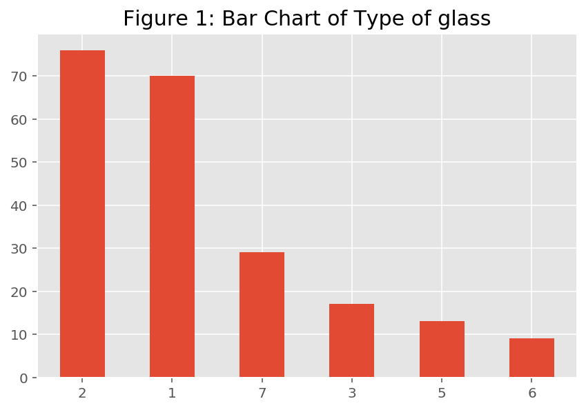

```python
ax = data['Type_of_glass'].value_counts().plot(kind = 'bar')
ax.set_xticklabels(ax.get_xticklabels(), rotation = 360)
plt.tight_layout()
plt.title('Figure 1: Bar Chart of Type of glass', fontsize = 15)
plt.show();
```

Let's display a boxplot and a histogram for refractive index. Figure 2 and Figure 3 show that this variable is right-skewed.

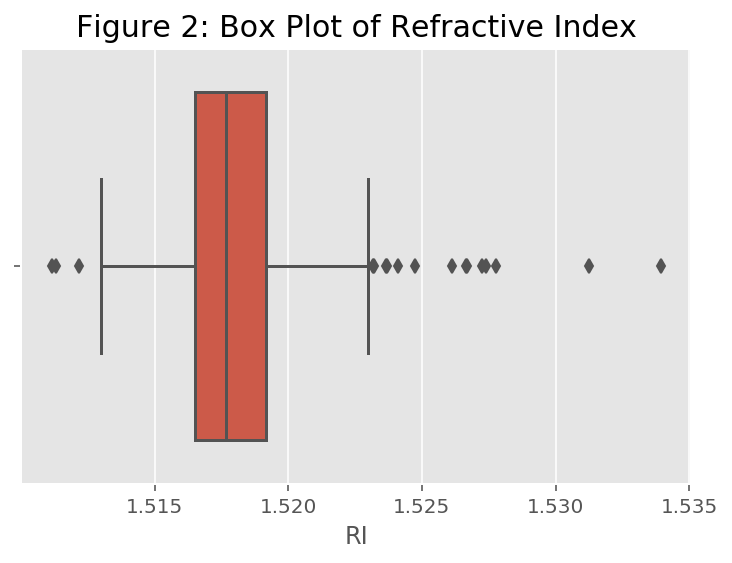

```python
# Creating a box plot of refractive index
sns.boxplot(data['RI']).set_title('Figure 2: Box Plot of Refractive Index', fontsize = 15)
plt.show();
```

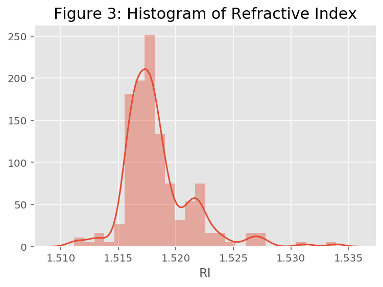

```python
# Creating a histogram of refractive index
sns.distplot(data['RI'], kde = True).set_title('Figure 3: Histogram of Refractive Index', fontsize = 15)
plt.show();
```

### Multivariate Visualisation

#### Scatterplot of Numeric Features and Refractive Index

The scatterplot in Figure 4 shows no clear correlation between the Refractive Index and Sodium numeric variables.

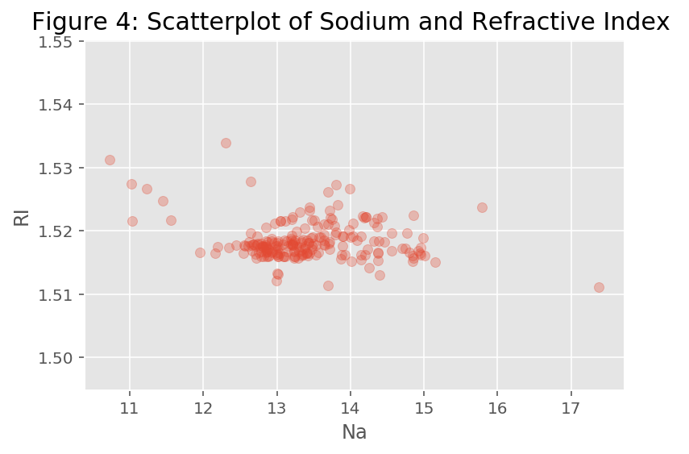

```python
# Storing the values of sodim
na = data['Na']

# Creating a scatter plot
plt.scatter(na, data['RI'], alpha = 0.3)
plt.title('Figure 4: Scatterplot of Sodium and Refractive Index ', fontsize = 15)
plt.xlabel('Na')
plt.ylabel('RI')
plt.show();
```

The scatterplot in Figure 5 shows no clear correlation between the Refractive Index and Magnesium numeric variables.

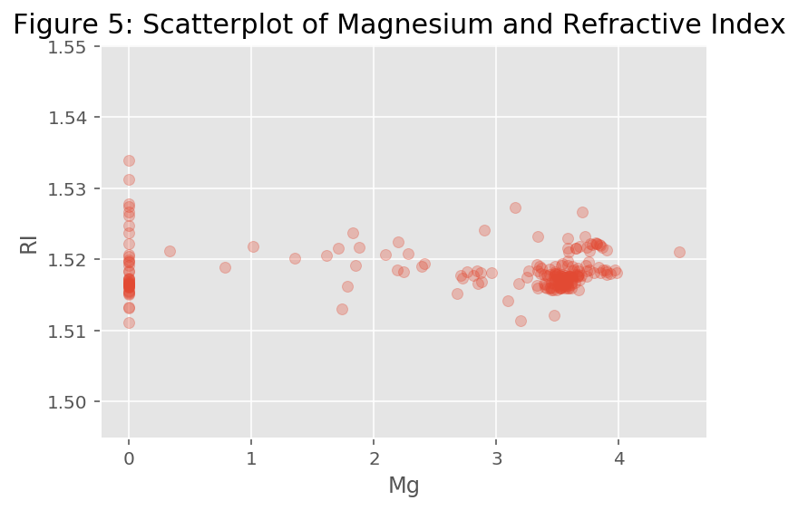

```python
mg = data['Mg']

# Creating a scatter plot
plt.scatter(mg, data['RI'], alpha = 0.3)
plt.title('Figure 5: Scatterplot of Magnesium and Refractive Index ', fontsize = 15)
plt.xlabel('Mg')
plt.ylabel('RI')
plt.show();
```

The scatterplot in Figure 6 shows a little bit negative correlation between the Refractive Index and Aluminum numeric variables.

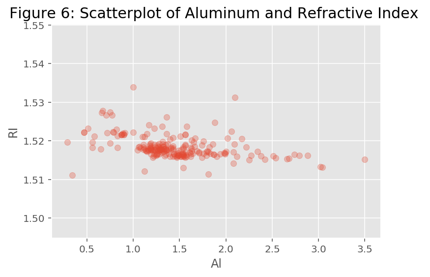

```python
al = data['Al']

# Creating a scatter plot
plt.scatter(al, data['RI'], alpha = 0.3)
plt.title('Figure 6: Scatterplot of Aluminum and Refractive Index ', fontsize = 15)
plt.xlabel('Al')
plt.ylabel('RI')
plt.show();
```

The scatterplot in Figure 7 shows a little bit negative correlation between the Refractive Index and Silicon numeric variables.

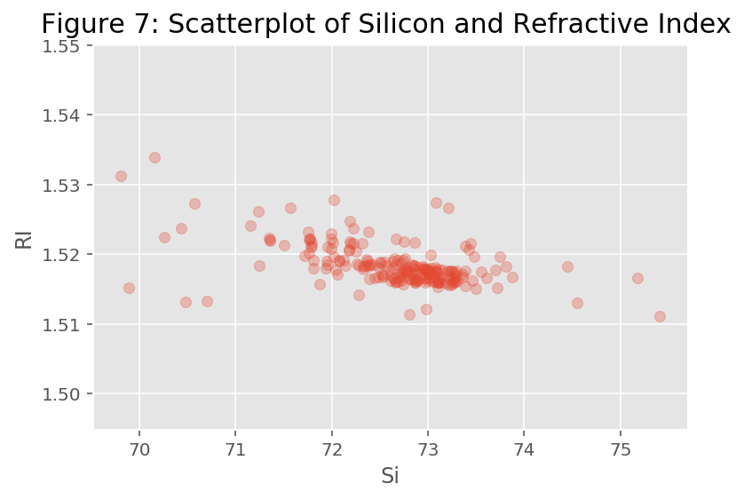

```python
si = data['Si']

# Creating a scatter plot
plt.scatter(si, data['RI'], alpha = 0.3)
plt.title('Figure 7: Scatterplot of Silicon and Refractive Index ', fontsize = 15)
plt.xlabel('Si')
plt.ylabel('RI')
plt.show();
```

The scatterplot in Figure 8 shows no clear correlation between the Refractive Index and Potassium numeric variables.

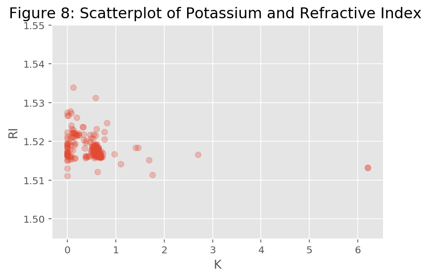

```python
k = data['K']

# Creating a scatter plot
plt.scatter(k, data['RI'], alpha = 0.3)
plt.title('Figure 8: Scatterplot of Potassium and Refractive Index ', fontsize = 15)
plt.xlabel('K')
plt.ylabel('RI')
plt.show();
```

The scatterplot in Figure 9 shows a positive correlation between the Refractive Index and Calcium numeric variables.

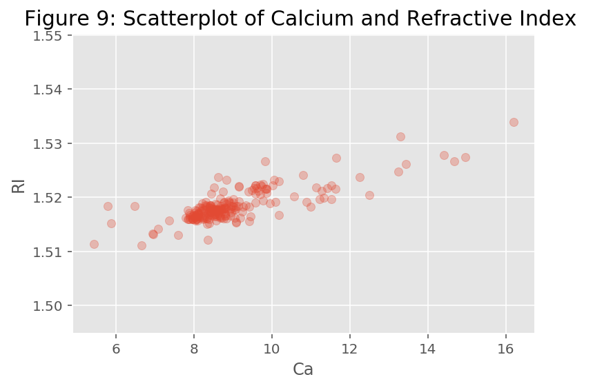

```python
ca = data['Ca']

# Creating a scatter plot
plt.scatter(ca, data['RI'], alpha = 0.3)
plt.title('Figure 9: Scatterplot of Calcium and Refractive Index ', fontsize = 15)
plt.xlabel('Ca')
plt.ylabel('RI')
plt.show();
```

The scatterplot in Figure 10 shows no clear correlation between the Refractive Index and Barium numeric variables.

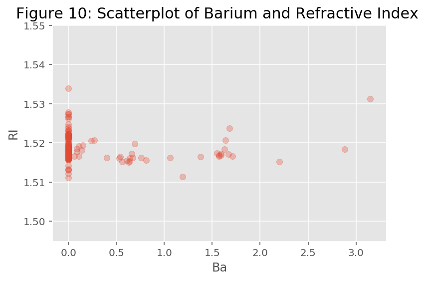

```python
ba = data['Ba']

# Creating a scatter plot
plt.scatter(ba, data['RI'], alpha = 0.3)
plt.title('Figure 10: Scatterplot of Barium and Refractive Index ', fontsize = 15)
plt.xlabel('Ba')
plt.ylabel('RI')
plt.show();
```

The scatterplot in Figure 11 shows no clear correlation between the Refractive Index and Iron numeric variables.

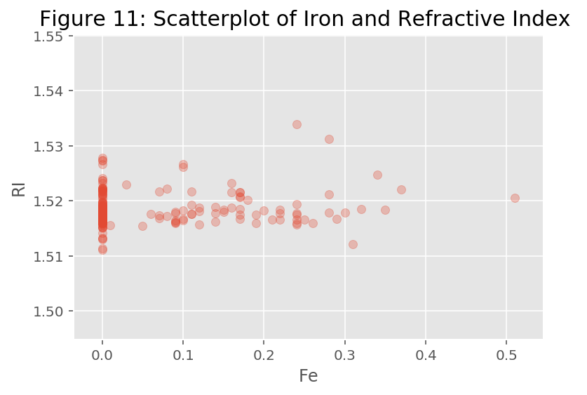

```python
fe = data['Fe']

# Creating a scatter plot
plt.scatter(fe, data['RI'], alpha = 0.3)
plt.title('Figure 11: Scatterplot of Iron and Refractive Index ', fontsize = 15)
plt.xlabel('Fe')
plt.ylabel('RI')
plt.show();
```

**So generally there is a little negative correlation between Refractive Index and both Aluminum and Silicon numeric variables. And there is clearly a positive correlation between Refractive Index and Calcium. But for other numeric variables, there are no clearly correlation.**

#### Categorical Attributes

```
We can see that the distribution of RI between each type of glass is partially similar, their mean are quite close but the Q3 are not
```

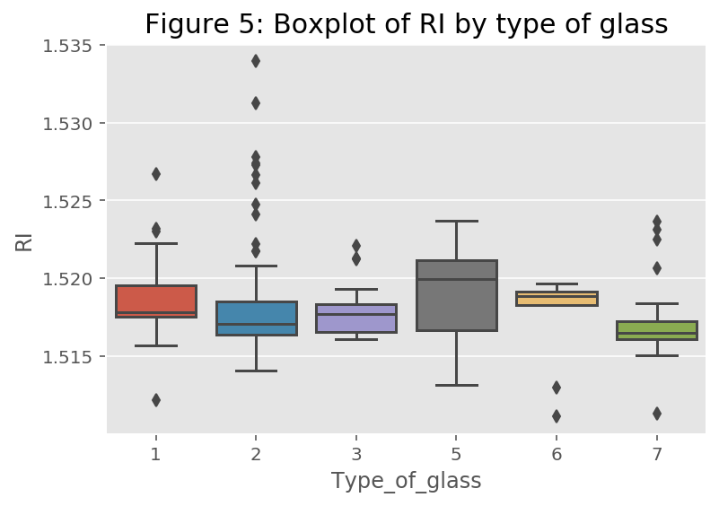

```python
print("We can see that the distribution of RI between each type of glass is partially similar, their mean are quite close but the Q3 are not");
#creating a boxplot
sns.boxplot(data['Type_of_glass'], data['RI']);
plt.title('Figure 5: Boxplot of RI by type of glass', fontsize=15)
plt.show();
```

# **Statistical Modeling and Performance Evaluation**

### **Full model**

We begin by fitting a multiple linear regression that predicts RI using all of the avaliable features. We call this the full model. First let's take a quick peak at the clean data.

```python
data.head()
```

|  | RI | Na | Mg | Al | Si | K | Ca | Ba | Fe | Type_of_glass |
| --- | --- | --- | --- | --- | --- | --- | --- | --- | --- | --- |
| 0 | 1.52101 | 13.64 | 4.49 | 1.10 | 71.78 | 0.06 | 8.75 | 0.0 | 0.0 | 1 |
| 1 | 1.51761 | 13.89 | 3.60 | 1.36 | 72.73 | 0.48 | 7.83 | 0.0 | 0.0 | 1 |
| 2 | 1.51618 | 13.53 | 3.55 | 1.54 | 72.99 | 0.39 | 7.78 | 0.0 | 0.0 | 1 |
| 3 | 1.51766 | 13.21 | 3.69 | 1.29 | 72.61 | 0.57 | 8.22 | 0.0 | 0.0 | 1 |
| 4 | 1.51742 | 13.27 | 3.62 | 1.24 | 73.08 | 0.55 | 8.07 | 0.0 | 0.0 | 1 |

When constructing the regression formula, we can manually add all the independent features. On the other hand, if there are lots of independent variables, we can get smart and use some string function tricks as below.

```python
formula_string_indep_vars = ' + '.join(data.drop(columns='RI').columns)
formula_string = 'RI ~ ' + formula_string_indep_vars
print('formula_string: ', formula_string)
```

```
formula_string:  RI ~ Na + Mg + Al + Si + K + Ca + Ba + Fe + Type_of_glass
```

In the code chunk below, we first use the get_dummies() function in Pandas for one-hot-encoding of categorical features and then we construct a new formula string with the encoded features.

```python
data_encoded = pd.get_dummies(data, drop_first=True)
data_encoded.head()
```

|  | RI | Na | Mg | Al | Si | K | Ca | Ba | Fe | Type_of_glass_2 | Type_of_glass_3 | Type_of_glass_5 | Type_of_glass_6 | Type_of_glass_7 |
| --- | --- | --- | --- | --- | --- | --- | --- | --- | --- | --- | --- | --- | --- | --- |
| 0 | 1.52101 | 13.64 | 4.49 | 1.10 | 71.78 | 0.06 | 8.75 | 0.0 | 0.0 | 0 | 0 | 0 | 0 | 0 |
| 1 | 1.51761 | 13.89 | 3.60 | 1.36 | 72.73 | 0.48 | 7.83 | 0.0 | 0.0 | 0 | 0 | 0 | 0 | 0 |
| 2 | 1.51618 | 13.53 | 3.55 | 1.54 | 72.99 | 0.39 | 7.78 | 0.0 | 0.0 | 0 | 0 | 0 | 0 | 0 |
| 3 | 1.51766 | 13.21 | 3.69 | 1.29 | 72.61 | 0.57 | 8.22 | 0.0 | 0.0 | 0 | 0 | 0 | 0 | 0 |
| 4 | 1.51742 | 13.27 | 3.62 | 1.24 | 73.08 | 0.55 | 8.07 | 0.0 | 0.0 | 0 | 0 | 0 | 0 | 0 |

```python
formula_string_indep_vars_encoded = ' + '.join(data_encoded.drop(columns='RI').columns)
formula_string_encoded = 'RI ~ ' + formula_string_indep_vars_encoded
print('formula_string_encoded: ', formula_string_encoded)
```

```
formula_string_encoded:  RI ~ Na + Mg + Al + Si + K + Ca + Ba + Fe + Type_of_glass_2 + Type_of_glass_3 + Type_of_glass_5 + Type_of_glass_6 + Type_of_glass_7
```

Now that we have defined our statistical model formula as a Python string, we fit an OLS (ordinary least squares) model to our encoded data.

```python
model_full = sm.formula.ols(formula=formula_string_encoded, data=data_encoded)
###
model_full_fitted = model_full.fit()
###
print(model_full_fitted.summary())
```

```
                            OLS Regression Results
==============================================================================
Dep. Variable:                     RI   R-squared:                       0.908
Model:                            OLS   Adj. R-squared:                  0.902
Method:                 Least Squares   F-statistic:                     152.0
Date:                Sun, 27 Oct 2019   Prob (F-statistic):           5.47e-96
Time:                        22:19:24   Log-Likelihood:                 1192.8
No. Observations:                 214   AIC:                            -2358.
Df Residuals:                     200   BIC:                            -2310.
Df Model:                          13
Covariance Type:            nonrobust
===================================================================================
                      coef    std err          t      P>|t|      [0.025      0.975]
-----------------------------------------------------------------------------------
Intercept           1.5297      0.068     22.585      0.000       1.396       1.663
Na                  0.0006      0.001      0.912      0.363      -0.001       0.002
Mg                  0.0013      0.001      1.963      0.051   -6.29e-06       0.003
Al                 -0.0009      0.001     -1.318      0.189      -0.002       0.000
Si                 -0.0006      0.001     -0.900      0.369      -0.002       0.001
K                   0.0007      0.001      1.076      0.283      -0.001       0.002
Ca                  0.0025      0.001      3.705      0.000       0.001       0.004
Ba                  0.0020      0.001      2.814      0.005       0.001       0.003
Fe                  0.0004      0.001      0.492      0.623      -0.001       0.002
Type_of_glass_2  9.996e-05      0.000      0.576      0.565      -0.000       0.000
Type_of_glass_3    -0.0009      0.000     -3.392      0.001      -0.001      -0.000
Type_of_glass_5     0.0004      0.000      1.006      0.316      -0.000       0.001
Type_of_glass_6     0.0004      0.000      0.924      0.357      -0.000       0.001
Type_of_glass_7     0.0016      0.000      3.605      0.000       0.001       0.002
==============================================================================
Omnibus:                       46.064   Durbin-Watson:                   2.138
Prob(Omnibus):                  0.000   Jarque-Bera (JB):              631.101
Skew:                          -0.172   Prob(JB):                    9.08e-138
Kurtosis:                      11.406   Cond. No.                     7.77e+04
==============================================================================

Warnings:
[1] Standard Errors assume that the covariance matrix of the errors is correctly specified.
[2] The condition number is large, 7.77e+04. This might indicate that there are
strong multicollinearity or other numerical problems.
```

Let's plot actual Refractive Index values vs. predicted values.

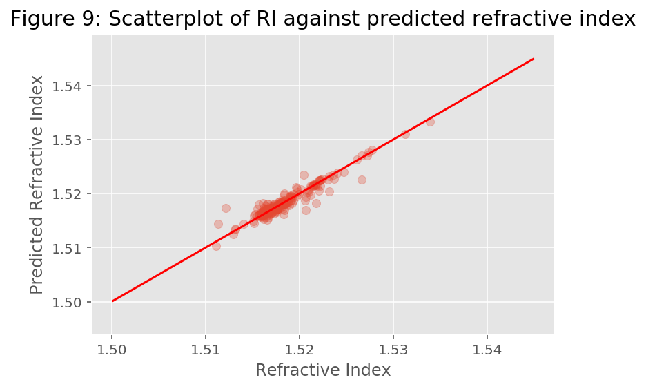

```python
def plot_line(axis, slope, intercept, **kargs):
    xmin, xmax = axis.get_xlim()
    plt.plot([xmin, xmax], [xmin*slope+intercept, xmax*slope+intercept], **kargs)

# Creating scatter plot
plt.scatter(data_encoded['RI'], model_full_fitted.fittedvalues, alpha=0.3);
plot_line(axis=plt.gca(), slope=1, intercept=0, c="red");
plt.xlabel('Refractive Index');
plt.ylabel('Predicted Refractive Index');
plt.title('Figure 9: Scatterplot of RI against predicted refractive index', fontsize=15);
plt.show();
```

### Full Model Diagnostic Checks

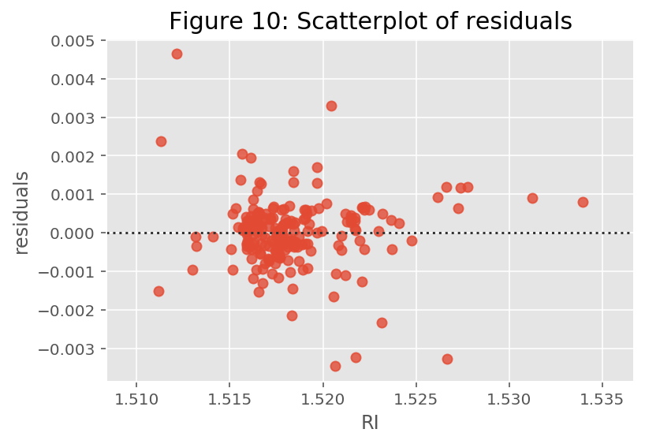

```python
sns.residplot(x=data_encoded['RI'], y=model_full_fitted.fittedvalues);
plt.ylabel('residuals')
plt.title('Figure 10: Scatterplot of residuals', fontsize=15)
plt.show();
```

From Figure 10, we see that the residuals appear mostly random and centered slightly below 0. The exception is some of those below the refractive index of 1.515 for whom the model predicts higher refractive index while some of those between the refractive index of 1.520 and 1.530 for whom the model predicts lower refractive index. Let's also look at the histogram of the residuals.

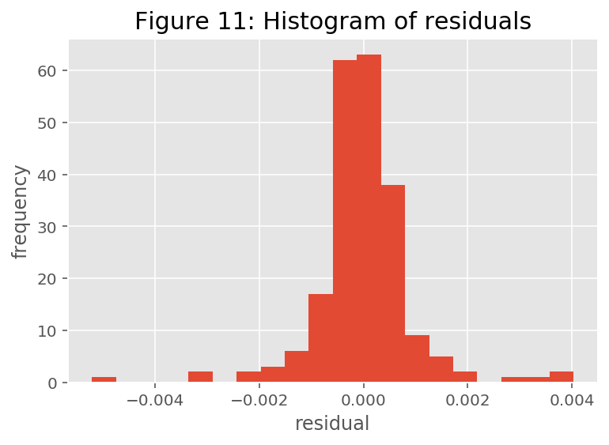

```python
residuals = data_encoded['RI'] - model_full_fitted.fittedvalues
plt.hist(residuals, bins = 20);
plt.xlabel('residual');
plt.ylabel('frequency');
plt.title('Figure 11: Histogram of residuals', fontsize=15);
plt.show();
```

From Figure 11, the histogram of residuals looks somewhat symmetric and slightly left-skewed. This suggests that the residuals are somewhat normally distributed.

### Backwards Feature Selection

```
We now perform backwards feature selection using p-value

Performing backwards feature selection using p-values:

Removing term "Fe" with p-value 0.6234

Removing term "Type_of_glass_2" with p-value 0.5663

Removing term "Na" with p-value 0.4956

Removing term "K" with p-value 0.3984

Removing term "Type_of_glass_6" with p-value 0.5102

Removing term "Type_of_glass_5" with p-value 0.3715

***
                            OLS Regression Results
==============================================================================
Dep. Variable:                     RI   R-squared:                       0.907
Model:                            OLS   Adj. R-squared:                  0.904
Method:                 Least Squares   F-statistic:                     286.0
Date:                Sun, 27 Oct 2019   Prob (F-statistic):          2.09e-102
Time:                        22:19:25   Log-Likelihood:                 1191.2
No. Observations:                 214   AIC:                            -2366.
Df Residuals:                     206   BIC:                            -2339.
Df Model:                           7
Covariance Type:            nonrobust
===================================================================================
                      coef    std err          t      P>|t|      [0.025      0.975]
-----------------------------------------------------------------------------------
Intercept           1.5969      0.008    188.104      0.000       1.580       1.614
Mg                  0.0006      0.000      5.807      0.000       0.000       0.001
Al                 -0.0015      0.000     -7.390      0.000      -0.002      -0.001
Si                 -0.0013      0.000    -12.161      0.000      -0.002      -0.001
Ca                  0.0018   8.41e-05     21.320      0.000       0.002       0.002
Ba                  0.0013      0.000      6.328      0.000       0.001       0.002
Type_of_glass_3    -0.0010      0.000     -3.997      0.000      -0.001      -0.000
Type_of_glass_7     0.0013      0.000      4.041      0.000       0.001       0.002
==============================================================================
Omnibus:                       45.350   Durbin-Watson:                   2.108
Prob(Omnibus):                  0.000   Jarque-Bera (JB):              627.258
Skew:                          -0.111   Prob(JB):                    6.20e-137
Kurtosis:                      11.384   Cond. No.                     9.65e+03
==============================================================================

Warnings:
[1] Standard Errors assume that the covariance matrix of the errors is correctly specified.
[2] The condition number is large, 9.65e+03. This might indicate that there are
strong multicollinearity or other numerical problems.
***
Regression number of terms: 8
Regression F-distribution p-value: 0.0000
Regression R-squared: 0.9067
Regression Adjusted R-squared: 0.9035
```

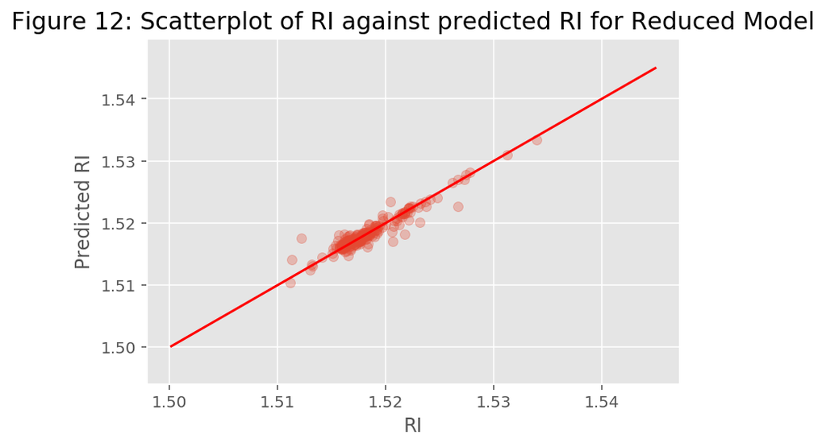

```
Figure 12 suggesting that the model successfully predict the RI
```

```python
print('We now perform backwards feature selection using p-value')
## create the patsy model description from formula
patsy_description = patsy.ModelDesc.from_formula(formula_string_encoded)

# initialize feature-selected fit to full model
linreg_fit = model_full_fitted

# do backwards elimination using p-values
p_val_cutoff = 0.05

## WARNING 1: The code below assumes that the Intercept term is present in the model.
## WARNING 2: It will work only with main effects and two-way interactions, if any.

print('\nPerforming backwards feature selection using p-values:')

while True:

    # uncomment the line below if you would like to see the regression summary
    # in each step:
    ### print(linreg_fit.summary())

    pval_series = linreg_fit.pvalues.drop(labels='Intercept')
    pval_series = pval_series.sort_values(ascending=False)
    term = pval_series.index[0]
    pval = pval_series[0]
    if (pval < p_val_cutoff):
        break
    term_components = term.split(':')
    print(f'\nRemoving term "{term}" with p-value {pval:.4}')
    if (len(term_components) == 1): ## this is a main effect term
        patsy_description.rhs_termlist.remove(patsy.Term([patsy.EvalFactor(term_components[0])]))
    else: ## this is an interaction term
        patsy_description.rhs_termlist.remove(patsy.Term([patsy.EvalFactor(term_components[0]),
                                                        patsy.EvalFactor(term_components[1])]))

    linreg_fit = smf.ols(formula=patsy_description, data=data_encoded).fit()

###
## this is the clean fit after backwards elimination
model_reduced_fitted = smf.ols(formula = patsy_description, data = data_encoded).fit()
###

#########
print("\n***")
print(model_reduced_fitted.summary())
print("***")
print(f"Regression number of terms: {len(model_reduced_fitted.model.exog_names)}")
print(f"Regression F-distribution p-value: {model_reduced_fitted.f_pvalue:.4f}")
print(f"Regression R-squared: {model_reduced_fitted.rsquared:.4f}")
print(f"Regression Adjusted R-squared: {model_reduced_fitted.rsquared_adj:.4f}")
print('\n');
# Creating scatter plot
plt.scatter(data['RI'], model_reduced_fitted.fittedvalues, alpha=0.3);
plot_line(axis=plt.gca(), slope=1, intercept=0, c="red");
plt.xlabel('RI');
plt.ylabel('Predicted RI');
plt.title('Figure 12: Scatterplot of RI against predicted RI for Reduced Model', fontsize=15);
plt.show();
print('Figure 12 suggesting that the model successfully predict the RI')
```

### Reduced Model Diagnostic Checks

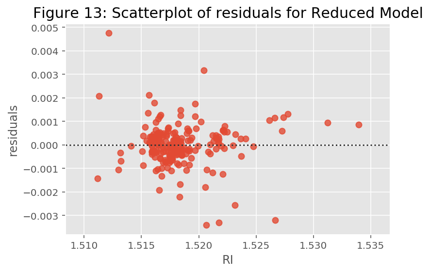

```
From Figure 13, we know that most of the residuals are centered around 0, the exception is those RI around 1.510 and some appeared between 1.520 and 1.525
```

```python
sns.residplot(x=data_encoded['RI'],  y=model_reduced_fitted.fittedvalues);
plt.ylabel('residuals')
plt.title('Figure 13: Scatterplot of residuals for Reduced Model', fontsize=15)
plt.show();
print('From Figure 13, we know that most of the residuals are centered around 0, the exception is those RI around 1.510 and some appeared between 1.520 and 1.525')
```

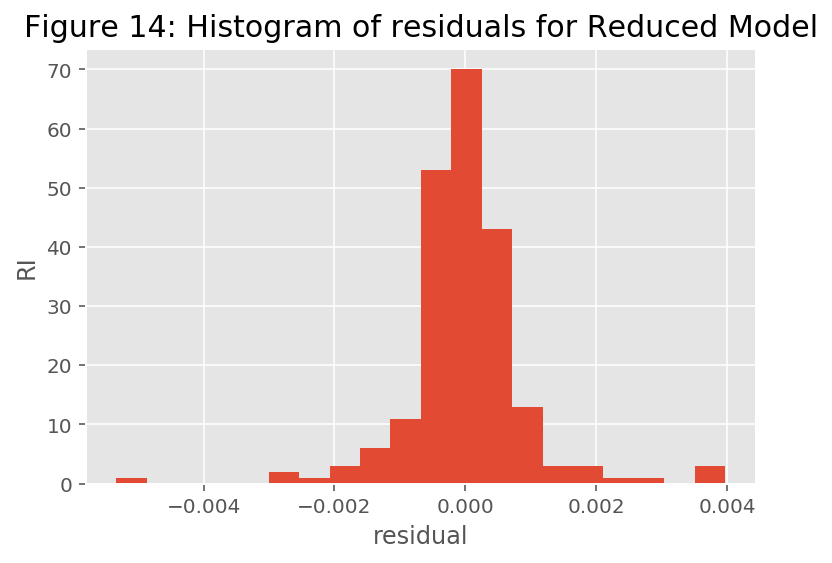

```python
residuals2 = data_encoded['RI'] - model_reduced_fitted.fittedvalues
plt.hist(residuals2, bins = 20);
plt.xlabel('residual');
plt.ylabel('RI');
plt.title('Figure 14: Histogram of residuals for Reduced Model', fontsize = 15)
plt.show();
```

From Figure 14 above, again there is a somewhat symmetric histogram around zero, which suggests that the residuals are somewhat normally distributed.

## References

B. German. Glass Identification Data Set. UCI Machine Learning Repository [online].Available at https://archive.ics.uci.edu/ml/datasets/glass+identification?fbclid=IwAR0Z4yFoW4g3woJxC7bGUVKnrnr9AzMAwqc-TeF_GuDOF5f9qkeXdkTeNZ4